# Risk Factor Analysis

## Outcome Variable

**Outcome Variable:** ever_stunted

## Predictor Variables

**Intervention Variable:** exclfeed3

**Adjustment Set:**

- arm
- brthmon
- W_mage
- meducyrs
- feducyrs
- hhwealth_quart
- hfoodsec
- W_mhtcm
- W_mwtkg
- W_mbmi
- vagbrth
- W_gagebrth
- W_birthwt
- W_birthlen
- W_nrooms
- W_nchldlt5
- month
- W_parity
- impfloor
- impsan
- safeh20
- delta_W_mage
- delta_meducyrs
- delta_feducyrs
- delta_hhwealth_quart
- delta_hfoodsec
- delta_W_mhtcm
- delta_W_mwtkg
- delta_W_mbmi
- delta_vagbrth
- delta_W_gagebrth
- delta_W_birthwt
- delta_W_birthlen
- delta_W_nrooms
- delta_W_nchldlt5
- delta_month
- delta_W_parity
- delta_impfloor
- delta_impsan
- delta_safeh20

## Stratifying Variables

The analysis was stratified on these variable(s):

- agecat
- studyid
- country

## Data Summary

| agecat | studyid | country | exclfeed3 | ever_stunted | n_cell | n |
| --- | --- | --- | --- | --- | --- | --- |
| 0-24 months (no birth st.) | CMC-V-BCS-2002 | INDIA | 1 | 0 | 0 | 8 |
| 0-24 months (no birth st.) | CMC-V-BCS-2002 | INDIA | 1 | 1 | 8 | 8 |
| 0-24 months (no birth st.) | CMC-V-BCS-2002 | INDIA | 0 | 0 | 0 | 8 |
| 0-24 months (no birth st.) | CMC-V-BCS-2002 | INDIA | 0 | 1 | 0 | 8 |
| 0-24 months (no birth st.) | EE | PAKISTAN | 1 | 0 | 4 | 21 |
| 0-24 months (no birth st.) | EE | PAKISTAN | 1 | 1 | 17 | 21 |
| 0-24 months (no birth st.) | EE | PAKISTAN | 0 | 0 | 0 | 21 |
| 0-24 months (no birth st.) | EE | PAKISTAN | 0 | 1 | 0 | 21 |
| 0-24 months (no birth st.) | GMS-Nepal | NEPAL | 1 | 0 | 116 | 380 |
| 0-24 months (no birth st.) | GMS-Nepal | NEPAL | 1 | 1 | 201 | 380 |
| 0-24 months (no birth st.) | GMS-Nepal | NEPAL | 0 | 0 | 22 | 380 |
| 0-24 months (no birth st.) | GMS-Nepal | NEPAL | 0 | 1 | 41 | 380 |
| 0-24 months (no birth st.) | IRC | INDIA | 1 | 0 | 0 | 10 |
| 0-24 months (no birth st.) | IRC | INDIA | 1 | 1 | 0 | 10 |
| 0-24 months (no birth st.) | IRC | INDIA | 0 | 0 | 3 | 10 |
| 0-24 months (no birth st.) | IRC | INDIA | 0 | 1 | 7 | 10 |
| 0-24 months (no birth st.) | JiVitA-3 | BANGLADESH | 1 | 0 | 6792 | 10148 |
| 0-24 months (no birth st.) | JiVitA-3 | BANGLADESH | 1 | 1 | 2424 | 10148 |
| 0-24 months (no birth st.) | JiVitA-3 | BANGLADESH | 0 | 0 | 689 | 10148 |
| 0-24 months (no birth st.) | JiVitA-3 | BANGLADESH | 0 | 1 | 243 | 10148 |
| 0-24 months (no birth st.) | JiVitA-4 | BANGLADESH | 1 | 0 | 63 | 113 |
| 0-24 months (no birth st.) | JiVitA-4 | BANGLADESH | 1 | 1 | 40 | 113 |
| 0-24 months (no birth st.) | JiVitA-4 | BANGLADESH | 0 | 0 | 4 | 113 |
| 0-24 months (no birth st.) | JiVitA-4 | BANGLADESH | 0 | 1 | 6 | 113 |
| 0-24 months (no birth st.) | Keneba | GAMBIA | 1 | 0 | 759 | 1835 |
| 0-24 months (no birth st.) | Keneba | GAMBIA | 1 | 1 | 874 | 1835 |
| 0-24 months (no birth st.) | Keneba | GAMBIA | 0 | 0 | 91 | 1835 |
| 0-24 months (no birth st.) | Keneba | GAMBIA | 0 | 1 | 111 | 1835 |
| 0-24 months (no birth st.) | MAL-ED | BANGLADESH | 1 | 0 | 61 | 202 |
| 0-24 months (no birth st.) | MAL-ED | BANGLADESH | 1 | 1 | 71 | 202 |

[output cut: 162 more lines]

The following strata were considered:

- agecat: 0-24 months (no birth st.), studyid: CMC-V-BCS-2002, country: INDIA
- agecat: 0-24 months (no birth st.), studyid: EE, country: PAKISTAN
- agecat: 0-24 months (no birth st.), studyid: GMS-Nepal, country: NEPAL
- agecat: 0-24 months (no birth st.), studyid: IRC, country: INDIA
- agecat: 0-24 months (no birth st.), studyid: JiVitA-3, country: BANGLADESH
- agecat: 0-24 months (no birth st.), studyid: JiVitA-4, country: BANGLADESH
- agecat: 0-24 months (no birth st.), studyid: Keneba, country: GAMBIA
- agecat: 0-24 months (no birth st.), studyid: MAL-ED, country: BANGLADESH
- agecat: 0-24 months (no birth st.), studyid: MAL-ED, country: BRAZIL
- agecat: 0-24 months (no birth st.), studyid: MAL-ED, country: INDIA
- agecat: 0-24 months (no birth st.), studyid: MAL-ED, country: NEPAL
- agecat: 0-24 months (no birth st.), studyid: MAL-ED, country: PERU
- agecat: 0-24 months (no birth st.), studyid: MAL-ED, country: SOUTH AFRICA
- agecat: 0-24 months (no birth st.), studyid: MAL-ED, country: TANZANIA, UNITED REPUBLIC OF
- agecat: 0-24 months (no birth st.), studyid: PROVIDE, country: BANGLADESH
- agecat: 0-24 months (no birth st.), studyid: SAS-CompFeed, country: INDIA
- agecat: 0-6 months (no birth st.), studyid: CMC-V-BCS-2002, country: INDIA
- agecat: 0-6 months (no birth st.), studyid: EE, country: PAKISTAN
- agecat: 0-6 months (no birth st.), studyid: GMS-Nepal, country: NEPAL
- agecat: 0-6 months (no birth st.), studyid: IRC, country: INDIA
- agecat: 0-6 months (no birth st.), studyid: JiVitA-3, country: BANGLADESH
- agecat: 0-6 months (no birth st.), studyid: JiVitA-4, country: BANGLADESH
- agecat: 0-6 months (no birth st.), studyid: Keneba, country: GAMBIA
- agecat: 0-6 months (no birth st.), studyid: MAL-ED, country: BANGLADESH
- agecat: 0-6 months (no birth st.), studyid: MAL-ED, country: BRAZIL
- agecat: 0-6 months (no birth st.), studyid: MAL-ED, country: INDIA
- agecat: 0-6 months (no birth st.), studyid: MAL-ED, country: NEPAL
- agecat: 0-6 months (no birth st.), studyid: MAL-ED, country: PERU
- agecat: 0-6 months (no birth st.), studyid: MAL-ED, country: SOUTH AFRICA
- agecat: 0-6 months (no birth st.), studyid: MAL-ED, country: TANZANIA, UNITED REPUBLIC OF
- agecat: 0-6 months (no birth st.), studyid: PROVIDE, country: BANGLADESH
- agecat: 0-6 months (no birth st.), studyid: SAS-CompFeed, country: INDIA
- agecat: 6-24 months, studyid: CMC-V-BCS-2002, country: INDIA
- agecat: 6-24 months, studyid: EE, country: PAKISTAN
- agecat: 6-24 months, studyid: GMS-Nepal, country: NEPAL
- agecat: 6-24 months, studyid: IRC, country: INDIA
- agecat: 6-24 months, studyid: JiVitA-3, country: BANGLADESH
- agecat: 6-24 months, studyid: JiVitA-4, country: BANGLADESH
- agecat: 6-24 months, studyid: Keneba, country: GAMBIA
- agecat: 6-24 months, studyid: MAL-ED, country: BANGLADESH
- agecat: 6-24 months, studyid: MAL-ED, country: BRAZIL
- agecat: 6-24 months, studyid: MAL-ED, country: INDIA
- agecat: 6-24 months, studyid: MAL-ED, country: NEPAL
- agecat: 6-24 months, studyid: MAL-ED, country: PERU
- agecat: 6-24 months, studyid: MAL-ED, country: SOUTH AFRICA
- agecat: 6-24 months, studyid: MAL-ED, country: TANZANIA, UNITED REPUBLIC OF
- agecat: 6-24 months, studyid: PROVIDE, country: BANGLADESH
- agecat: 6-24 months, studyid: SAS-CompFeed, country: INDIA

### Dropped Strata

Some strata were dropped due to rare outcomes:

- agecat: 0-24 months (no birth st.), studyid: CMC-V-BCS-2002, country: INDIA
- agecat: 0-24 months (no birth st.), studyid: EE, country: PAKISTAN
- agecat: 0-24 months (no birth st.), studyid: IRC, country: INDIA
- agecat: 0-24 months (no birth st.), studyid: JiVitA-4, country: BANGLADESH
- agecat: 0-6 months (no birth st.), studyid: CMC-V-BCS-2002, country: INDIA
- agecat: 0-6 months (no birth st.), studyid: EE, country: PAKISTAN
- agecat: 0-6 months (no birth st.), studyid: IRC, country: INDIA
- agecat: 0-6 months (no birth st.), studyid: JiVitA-4, country: BANGLADESH
- agecat: 0-6 months (no birth st.), studyid: MAL-ED, country: NEPAL
- agecat: 6-24 months, studyid: CMC-V-BCS-2002, country: INDIA
- agecat: 6-24 months, studyid: EE, country: PAKISTAN
- agecat: 6-24 months, studyid: IRC, country: INDIA
- agecat: 6-24 months, studyid: JiVitA-4, country: BANGLADESH
- agecat: 6-24 months, studyid: MAL-ED, country: BRAZIL
- agecat: 6-24 months, studyid: MAL-ED, country: SOUTH AFRICA
- agecat: 6-24 months, studyid: SAS-CompFeed, country: INDIA

## Methods Detail

We’re interested in the causal parameters $E[Y_a]$ for all values of $a \in \mathcal{A}$. These parameters represent the mean outcome if, possibly contrary to fact, we intervened to set all units to have $A=a$. Under the randomization and positivity assumptions, these are identified by the statistical parameters $\psi_a=E_W[E_{Y|A,W}(Y|A=a,W)]$. In addition, we’re interested in the mean of $Y$, $E[Y]$ under no intervention (the observed mean). We will estimate these parameters by using SuperLearner to fit the relevant likelihood factors – $E_{Y|A,W}(Y|A=a,W)$ and $p(A=a|W)$, and then updating our likelihood fit using a joint TMLE.

For unadjusted analyses ($W=\{\}$), initial likelihoods were estimated using Lrnr_glm to estimate the simple $E(Y|A)$ and Lrnr_mean to estimate $p(A)$. For adjusted analyses, a small library containing Lrnr_glmnet, Lrnr_xgboost, and Lrnr_mean was used.

Having estimated these parameters, we will then use the delta method to estimate relative risks and attributable risks relative to a prespecified baseline level of $A$.

# Results Detail

## Results Plots

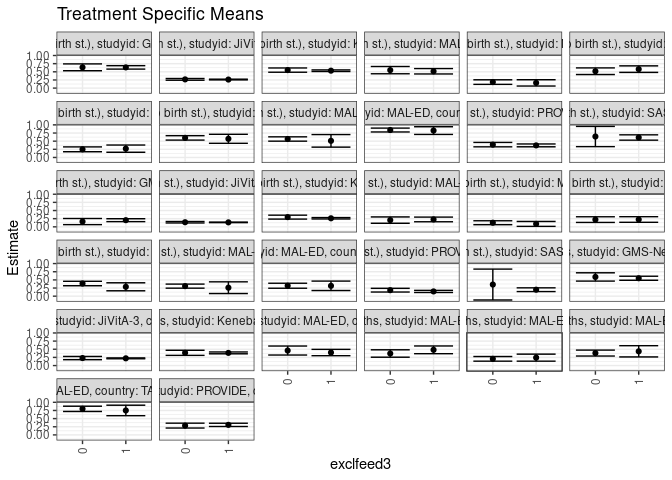

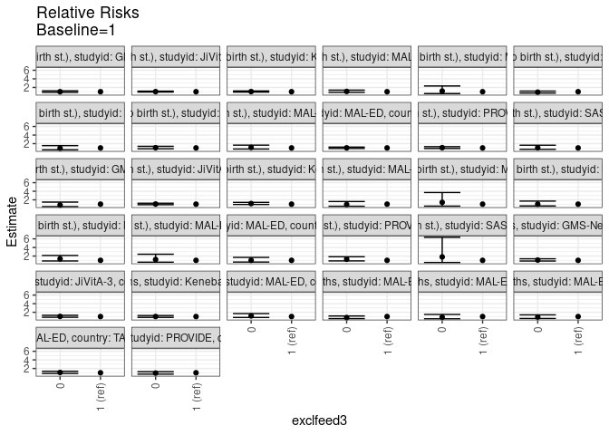

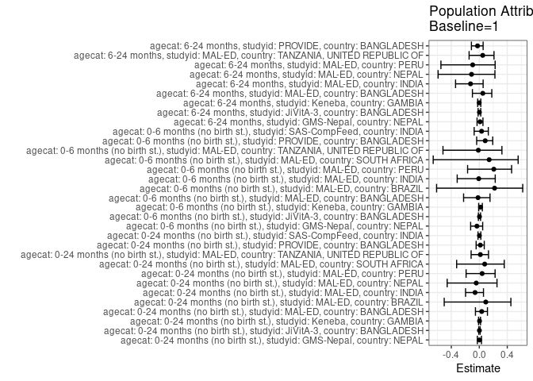

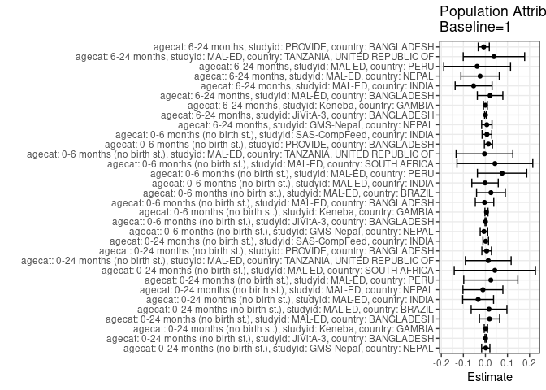

## Results Table

### Parameter: TSM

| agecat | studyid | country | intervention_level | baseline_level | estimate | ci_lower | ci_upper |
| --- | --- | --- | --- | --- | --- | --- | --- |
| 0-24 months (no birth st.) | GMS-Nepal | NEPAL | 1 | NA | 0.6353451 | 0.5826495 | 0.6880408 |
| 0-24 months (no birth st.) | GMS-Nepal | NEPAL | 0 | NA | 0.6379755 | 0.5329352 | 0.7430158 |
| 0-24 months (no birth st.) | JiVitA-3 | BANGLADESH | 1 | NA | 0.2623253 | 0.2515561 | 0.2730946 |
| 0-24 months (no birth st.) | JiVitA-3 | BANGLADESH | 0 | NA | 0.2673894 | 0.2409615 | 0.2938172 |
| 0-24 months (no birth st.) | Keneba | GAMBIA | 1 | NA | 0.5347566 | 0.5106914 | 0.5588218 |
| 0-24 months (no birth st.) | Keneba | GAMBIA | 0 | NA | 0.5526416 | 0.4871244 | 0.6181589 |
| 0-24 months (no birth st.) | MAL-ED | BANGLADESH | 1 | NA | 0.5160451 | 0.4330625 | 0.5990277 |
| 0-24 months (no birth st.) | MAL-ED | BANGLADESH | 0 | NA | 0.5513474 | 0.4396482 | 0.6630467 |
| 0-24 months (no birth st.) | MAL-ED | BRAZIL | 1 | NA | 0.1607143 | 0.0642469 | 0.2571817 |
| 0-24 months (no birth st.) | MAL-ED | BRAZIL | 0 | NA | 0.1848739 | 0.1149269 | 0.2548210 |
| 0-24 months (no birth st.) | MAL-ED | INDIA | 1 | NA | 0.5820131 | 0.4820985 | 0.6819276 |
| 0-24 months (no birth st.) | MAL-ED | INDIA | 0 | NA | 0.5180989 | 0.4162803 | 0.6199175 |
| 0-24 months (no birth st.) | MAL-ED | NEPAL | 1 | NA | 0.2700386 | 0.1591967 | 0.3808805 |
| 0-24 months (no birth st.) | MAL-ED | NEPAL | 0 | NA | 0.2501068 | 0.1762431 | 0.3239704 |
| 0-24 months (no birth st.) | MAL-ED | PERU | 1 | NA | 0.5724255 | 0.4348237 | 0.7100273 |
| 0-24 months (no birth st.) | MAL-ED | PERU | 0 | NA | 0.6009143 | 0.5330171 | 0.6688115 |
| 0-24 months (no birth st.) | MAL-ED | SOUTH AFRICA | 1 | NA | 0.5100553 | 0.3172018 | 0.7029087 |
| 0-24 months (no birth st.) | MAL-ED | SOUTH AFRICA | 0 | NA | 0.5669835 | 0.5003764 | 0.6335907 |
| 0-24 months (no birth st.) | MAL-ED | TANZANIA, UNITED REPUBLIC OF | 1 | NA | 0.8250000 | 0.7069296 | 0.9430704 |
| 0-24 months (no birth st.) | MAL-ED | TANZANIA, UNITED REPUBLIC OF | 0 | NA | 0.8413793 | 0.7817559 | 0.9010027 |
| 0-24 months (no birth st.) | PROVIDE | BANGLADESH | 1 | NA | 0.3704435 | 0.3268796 | 0.4140074 |
| 0-24 months (no birth st.) | PROVIDE | BANGLADESH | 0 | NA | 0.3932911 | 0.3258051 | 0.4607772 |
| 0-24 months (no birth st.) | SAS-CompFeed | INDIA | 1 | NA | 0.6121795 | 0.5306906 | 0.6936683 |
| 0-24 months (no birth st.) | SAS-CompFeed | INDIA | 0 | NA | 0.6428571 | 0.3329177 | 0.9527966 |
| 0-6 months (no birth st.) | GMS-Nepal | NEPAL | 1 | NA | 0.2040562 | 0.1596467 | 0.2484656 |
| 0-6 months (no birth st.) | GMS-Nepal | NEPAL | 0 | NA | 0.1615094 | 0.0674651 | 0.2555537 |
| 0-6 months (no birth st.) | JiVitA-3 | BANGLADESH | 1 | NA | 0.1369257 | 0.1289754 | 0.1448760 |
| 0-6 months (no birth st.) | JiVitA-3 | BANGLADESH | 0 | NA | 0.1409167 | 0.1188409 | 0.1629926 |
| 0-6 months (no birth st.) | Keneba | GAMBIA | 1 | NA | 0.2617539 | 0.2404506 | 0.2830572 |
| 0-6 months (no birth st.) | Keneba | GAMBIA | 0 | NA | 0.2973381 | 0.2375479 | 0.3571282 |
| 0-6 months (no birth st.) | MAL-ED | BANGLADESH | 1 | NA | 0.2268080 | 0.1547623 | 0.2988536 |
| 0-6 months (no birth st.) | MAL-ED | BANGLADESH | 0 | NA | 0.2060471 | 0.1088554 | 0.3032387 |
| 0-6 months (no birth st.) | MAL-ED | BRAZIL | 1 | NA | 0.0892857 | 0.0143859 | 0.1641855 |
| 0-6 months (no birth st.) | MAL-ED | BRAZIL | 0 | NA | 0.1260504 | 0.0662459 | 0.1858550 |
| 0-6 months (no birth st.) | MAL-ED | INDIA | 1 | NA | 0.2245651 | 0.1387538 | 0.3103763 |
| 0-6 months (no birth st.) | MAL-ED | INDIA | 0 | NA | 0.2219380 | 0.1352491 | 0.3086269 |
| 0-6 months (no birth st.) | MAL-ED | PERU | 1 | NA | 0.2881184 | 0.1654950 | 0.4107419 |
| 0-6 months (no birth st.) | MAL-ED | PERU | 0 | NA | 0.3884762 | 0.3208244 | 0.4561280 |
| 0-6 months (no birth st.) | MAL-ED | SOUTH AFRICA | 1 | NA | 0.2608696 | 0.0810344 | 0.4407047 |
| 0-6 months (no birth st.) | MAL-ED | SOUTH AFRICA | 0 | NA | 0.3084112 | 0.2464031 | 0.3704193 |
| 0-6 months (no birth st.) | MAL-ED | TANZANIA, UNITED REPUBLIC OF | 1 | NA | 0.3178026 | 0.1731587 | 0.4624466 |
| 0-6 months (no birth st.) | MAL-ED | TANZANIA, UNITED REPUBLIC OF | 0 | NA | 0.3202968 | 0.2439514 | 0.3966423 |
| 0-6 months (no birth st.) | PROVIDE | BANGLADESH | 1 | NA | 0.1460355 | 0.1135533 | 0.1785177 |
| 0-6 months (no birth st.) | PROVIDE | BANGLADESH | 0 | NA | 0.1842635 | 0.1276401 | 0.2408868 |
| 0-6 months (no birth st.) | SAS-CompFeed | INDIA | 1 | NA | 0.1987179 | 0.1419130 | 0.2555229 |
| 0-6 months (no birth st.) | SAS-CompFeed | INDIA | 0 | NA | 0.3571429 | -0.1170496 | 0.8313354 |
| 6-24 months | GMS-Nepal | NEPAL | 1 | NA | 0.5503665 | 0.4885372 | 0.6121958 |
| 6-24 months | GMS-Nepal | NEPAL | 0 | NA | 0.5901760 | 0.4631716 | 0.7171805 |
| 6-24 months | JiVitA-3 | BANGLADESH | 1 | NA | 0.2216122 | 0.2086488 | 0.2345757 |
| 6-24 months | JiVitA-3 | BANGLADESH | 0 | NA | 0.2292803 | 0.1802992 | 0.2782614 |
| 6-24 months | Keneba | GAMBIA | 1 | NA | 0.3882617 | 0.3600256 | 0.4164977 |
| 6-24 months | Keneba | GAMBIA | 0 | NA | 0.3903704 | 0.3118157 | 0.4689251 |
| 6-24 months | MAL-ED | BANGLADESH | 1 | NA | 0.3988489 | 0.3014034 | 0.4962945 |
| 6-24 months | MAL-ED | BANGLADESH | 0 | NA | 0.4604424 | 0.3226724 | 0.5982123 |
| 6-24 months | MAL-ED | INDIA | 1 | NA | 0.4820992 | 0.3634305 | 0.6007678 |
| 6-24 months | MAL-ED | INDIA | 0 | NA | 0.3695782 | 0.2561443 | 0.4830120 |
| 6-24 months | MAL-ED | NEPAL | 1 | NA | 0.2422174 | 0.1343700 | 0.3500648 |
| 6-24 months | MAL-ED | NEPAL | 0 | NA | 0.2051987 | 0.1341078 | 0.2762895 |
| 6-24 months | MAL-ED | PERU | 1 | NA | 0.4362310 | 0.2642304 | 0.6082316 |
| 6-24 months | MAL-ED | PERU | 0 | NA | 0.3826582 | 0.2915438 | 0.4737727 |
| 6-24 months | MAL-ED | TANZANIA, UNITED REPUBLIC OF | 1 | NA | 0.7500000 | 0.5889568 | 0.9110432 |
| 6-24 months | MAL-ED | TANZANIA, UNITED REPUBLIC OF | 0 | NA | 0.8000000 | 0.7192358 | 0.8807642 |
| 6-24 months | PROVIDE | BANGLADESH | 1 | NA | 0.3080206 | 0.2580068 | 0.3580344 |
| 6-24 months | PROVIDE | BANGLADESH | 0 | NA | 0.2854641 | 0.2109338 | 0.3599943 |

### Parameter: E(Y)

| agecat | studyid | country | intervention_level | baseline_level | estimate | ci_lower | ci_upper |
| --- | --- | --- | --- | --- | --- | --- | --- |
| 0-24 months (no birth st.) | GMS-Nepal | NEPAL | NA | NA | 0.6368421 | 0.5884257 | 0.6852585 |
| 0-24 months (no birth st.) | JiVitA-3 | BANGLADESH | NA | NA | 0.2628104 | 0.2524838 | 0.2731371 |
| 0-24 months (no birth st.) | Keneba | GAMBIA | NA | NA | 0.5367847 | 0.5139635 | 0.5596060 |
| 0-24 months (no birth st.) | MAL-ED | BANGLADESH | NA | NA | 0.5346535 | 0.4656971 | 0.6036099 |
| 0-24 months (no birth st.) | MAL-ED | BRAZIL | NA | NA | 0.1771429 | 0.1204149 | 0.2338709 |
| 0-24 months (no birth st.) | MAL-ED | INDIA | NA | NA | 0.5489130 | 0.4768182 | 0.6210079 |
| 0-24 months (no birth st.) | MAL-ED | NEPAL | NA | NA | 0.2587065 | 0.1980144 | 0.3193985 |
| 0-24 months (no birth st.) | MAL-ED | PERU | NA | NA | 0.5968379 | 0.5362738 | 0.6574021 |
| 0-24 months (no birth st.) | MAL-ED | SOUTH AFRICA | NA | NA | 0.5527426 | 0.4893071 | 0.6161781 |
| 0-24 months (no birth st.) | MAL-ED | TANZANIA, UNITED REPUBLIC OF | NA | NA | 0.8378378 | 0.7845787 | 0.8910970 |
| 0-24 months (no birth st.) | PROVIDE | BANGLADESH | NA | NA | 0.3759874 | 0.3382238 | 0.4137509 |
| 0-24 months (no birth st.) | SAS-CompFeed | INDIA | NA | NA | 0.6134969 | 0.5286303 | 0.6983636 |
| 0-6 months (no birth st.) | GMS-Nepal | NEPAL | NA | NA | 0.1973684 | 0.1572979 | 0.2374390 |
| 0-6 months (no birth st.) | JiVitA-3 | BANGLADESH | NA | NA | 0.1373090 | 0.1297510 | 0.1448670 |
| 0-6 months (no birth st.) | Keneba | GAMBIA | NA | NA | 0.2664850 | 0.2462507 | 0.2867194 |
| 0-6 months (no birth st.) | MAL-ED | BANGLADESH | NA | NA | 0.2227723 | 0.1652475 | 0.2802970 |
| 0-6 months (no birth st.) | MAL-ED | BRAZIL | NA | NA | 0.1142857 | 0.0670124 | 0.1615591 |
| 0-6 months (no birth st.) | MAL-ED | INDIA | NA | NA | 0.2228261 | 0.1625334 | 0.2831188 |
| 0-6 months (no birth st.) | MAL-ED | PERU | NA | NA | 0.3636364 | 0.3042435 | 0.4230292 |
| 0-6 months (no birth st.) | MAL-ED | SOUTH AFRICA | NA | NA | 0.3037975 | 0.2451226 | 0.3624723 |
| 0-6 months (no birth st.) | MAL-ED | TANZANIA, UNITED REPUBLIC OF | NA | NA | 0.3135135 | 0.2464813 | 0.3805457 |
| 0-6 months (no birth st.) | PROVIDE | BANGLADESH | NA | NA | 0.1595577 | 0.1310079 | 0.1881074 |
| 0-6 months (no birth st.) | SAS-CompFeed | INDIA | NA | NA | 0.2055215 | 0.1385538 | 0.2724891 |
| 6-24 months | GMS-Nepal | NEPAL | NA | NA | 0.5566667 | 0.5003580 | 0.6129753 |
| 6-24 months | JiVitA-3 | BANGLADESH | NA | NA | 0.2220682 | 0.2093710 | 0.2347655 |
| 6-24 months | Keneba | GAMBIA | NA | NA | 0.3881064 | 0.3613784 | 0.4148344 |
| 6-24 months | MAL-ED | BANGLADESH | NA | NA | 0.4200000 | 0.3407510 | 0.4992490 |
| 6-24 months | MAL-ED | INDIA | NA | NA | 0.4285714 | 0.3463030 | 0.5108399 |
| 6-24 months | MAL-ED | NEPAL | NA | NA | 0.2180851 | 0.1588990 | 0.2772712 |
| 6-24 months | MAL-ED | PERU | NA | NA | 0.3986486 | 0.3194990 | 0.4777982 |
| 6-24 months | MAL-ED | TANZANIA, UNITED REPUBLIC OF | NA | NA | 0.7886179 | 0.7161684 | 0.8610674 |
| 6-24 months | PROVIDE | BANGLADESH | NA | NA | 0.3004386 | 0.2583143 | 0.3425629 |

### Parameter: RR

| agecat | studyid | country | intervention_level | baseline_level | estimate | ci_lower | ci_upper |
| --- | --- | --- | --- | --- | --- | --- | --- |
| 0-24 months (no birth st.) | GMS-Nepal | NEPAL | 1 | 1 | 1.0000000 | 1.0000000 | 1.000000 |
| 0-24 months (no birth st.) | GMS-Nepal | NEPAL | 0 | 1 | 1.0041400 | 0.8396700 | 1.200826 |
| 0-24 months (no birth st.) | JiVitA-3 | BANGLADESH | 1 | 1 | 1.0000000 | 1.0000000 | 1.000000 |
| 0-24 months (no birth st.) | JiVitA-3 | BANGLADESH | 0 | 1 | 1.0193045 | 0.9195016 | 1.129940 |
| 0-24 months (no birth st.) | Keneba | GAMBIA | 1 | 1 | 1.0000000 | 1.0000000 | 1.000000 |
| 0-24 months (no birth st.) | Keneba | GAMBIA | 0 | 1 | 1.0334452 | 0.9118978 | 1.171194 |
| 0-24 months (no birth st.) | MAL-ED | BANGLADESH | 1 | 1 | 1.0000000 | 1.0000000 | 1.000000 |
| 0-24 months (no birth st.) | MAL-ED | BANGLADESH | 0 | 1 | 1.0684093 | 0.8346842 | 1.367581 |
| 0-24 months (no birth st.) | MAL-ED | BRAZIL | 1 | 1 | 1.0000000 | 1.0000000 | 1.000000 |
| 0-24 months (no birth st.) | MAL-ED | BRAZIL | 0 | 1 | 1.1503268 | 0.5658150 | 2.338665 |
| 0-24 months (no birth st.) | MAL-ED | INDIA | 1 | 1 | 1.0000000 | 1.0000000 | 1.000000 |
| 0-24 months (no birth st.) | MAL-ED | INDIA | 0 | 1 | 0.8901843 | 0.6880305 | 1.151734 |
| 0-24 months (no birth st.) | MAL-ED | NEPAL | 1 | 1 | 1.0000000 | 1.0000000 | 1.000000 |
| 0-24 months (no birth st.) | MAL-ED | NEPAL | 0 | 1 | 0.9261891 | 0.5567500 | 1.540774 |
| 0-24 months (no birth st.) | MAL-ED | PERU | 1 | 1 | 1.0000000 | 1.0000000 | 1.000000 |
| 0-24 months (no birth st.) | MAL-ED | PERU | 0 | 1 | 1.0497686 | 0.8047587 | 1.369372 |
| 0-24 months (no birth st.) | MAL-ED | SOUTH AFRICA | 1 | 1 | 1.0000000 | 1.0000000 | 1.000000 |
| 0-24 months (no birth st.) | MAL-ED | SOUTH AFRICA | 0 | 1 | 1.1116120 | 0.7484318 | 1.651027 |
| 0-24 months (no birth st.) | MAL-ED | TANZANIA, UNITED REPUBLIC OF | 1 | 1 | 1.0000000 | 1.0000000 | 1.000000 |
| 0-24 months (no birth st.) | MAL-ED | TANZANIA, UNITED REPUBLIC OF | 0 | 1 | 1.0198537 | 0.8693236 | 1.196449 |
| 0-24 months (no birth st.) | PROVIDE | BANGLADESH | 1 | 1 | 1.0000000 | 1.0000000 | 1.000000 |
| 0-24 months (no birth st.) | PROVIDE | BANGLADESH | 0 | 1 | 1.0616765 | 0.8691405 | 1.296864 |
| 0-24 months (no birth st.) | SAS-CompFeed | INDIA | 1 | 1 | 1.0000000 | 1.0000000 | 1.000000 |
| 0-24 months (no birth st.) | SAS-CompFeed | INDIA | 0 | 1 | 1.0501122 | 0.6736522 | 1.636951 |
| 0-6 months (no birth st.) | GMS-Nepal | NEPAL | 1 | 1 | 1.0000000 | 1.0000000 | 1.000000 |
| 0-6 months (no birth st.) | GMS-Nepal | NEPAL | 0 | 1 | 0.7914948 | 0.4248824 | 1.474441 |
| 0-6 months (no birth st.) | JiVitA-3 | BANGLADESH | 1 | 1 | 1.0000000 | 1.0000000 | 1.000000 |
| 0-6 months (no birth st.) | JiVitA-3 | BANGLADESH | 0 | 1 | 1.0291474 | 0.8722844 | 1.214219 |
| 0-6 months (no birth st.) | Keneba | GAMBIA | 1 | 1 | 1.0000000 | 1.0000000 | 1.000000 |
| 0-6 months (no birth st.) | Keneba | GAMBIA | 0 | 1 | 1.1359450 | 0.9161424 | 1.408483 |
| 0-6 months (no birth st.) | MAL-ED | BANGLADESH | 1 | 1 | 1.0000000 | 1.0000000 | 1.000000 |
| 0-6 months (no birth st.) | MAL-ED | BANGLADESH | 0 | 1 | 0.9084649 | 0.5131880 | 1.608199 |
| 0-6 months (no birth st.) | MAL-ED | BRAZIL | 1 | 1 | 1.0000000 | 1.0000000 | 1.000000 |
| 0-6 months (no birth st.) | MAL-ED | BRAZIL | 0 | 1 | 1.4117647 | 0.5385303 | 3.700961 |
| 0-6 months (no birth st.) | MAL-ED | INDIA | 1 | 1 | 1.0000000 | 1.0000000 | 1.000000 |
| 0-6 months (no birth st.) | MAL-ED | INDIA | 0 | 1 | 0.9883016 | 0.5726886 | 1.705534 |
| 0-6 months (no birth st.) | MAL-ED | PERU | 1 | 1 | 1.0000000 | 1.0000000 | 1.000000 |
| 0-6 months (no birth st.) | MAL-ED | PERU | 0 | 1 | 1.3483212 | 0.8510646 | 2.136113 |
| 0-6 months (no birth st.) | MAL-ED | SOUTH AFRICA | 1 | 1 | 1.0000000 | 1.0000000 | 1.000000 |
| 0-6 months (no birth st.) | MAL-ED | SOUTH AFRICA | 0 | 1 | 1.1822430 | 0.5765601 | 2.424203 |
| 0-6 months (no birth st.) | MAL-ED | TANZANIA, UNITED REPUBLIC OF | 1 | 1 | 1.0000000 | 1.0000000 | 1.000000 |
| 0-6 months (no birth st.) | MAL-ED | TANZANIA, UNITED REPUBLIC OF | 0 | 1 | 1.0078483 | 0.6020377 | 1.687200 |
| 0-6 months (no birth st.) | PROVIDE | BANGLADESH | 1 | 1 | 1.0000000 | 1.0000000 | 1.000000 |
| 0-6 months (no birth st.) | PROVIDE | BANGLADESH | 0 | 1 | 1.2617713 | 0.8652948 | 1.839913 |
| 0-6 months (no birth st.) | SAS-CompFeed | INDIA | 1 | 1 | 1.0000000 | 1.0000000 | 1.000000 |
| 0-6 months (no birth st.) | SAS-CompFeed | INDIA | 0 | 1 | 1.7972350 | 0.5064696 | 6.377587 |
| 6-24 months | GMS-Nepal | NEPAL | 1 | 1 | 1.0000000 | 1.0000000 | 1.000000 |
| 6-24 months | GMS-Nepal | NEPAL | 0 | 1 | 1.0723327 | 0.8457472 | 1.359623 |
| 6-24 months | JiVitA-3 | BANGLADESH | 1 | 1 | 1.0000000 | 1.0000000 | 1.000000 |
| 6-24 months | JiVitA-3 | BANGLADESH | 0 | 1 | 1.0346013 | 0.8308586 | 1.288306 |
| 6-24 months | Keneba | GAMBIA | 1 | 1 | 1.0000000 | 1.0000000 | 1.000000 |
| 6-24 months | Keneba | GAMBIA | 0 | 1 | 1.0054313 | 0.8132164 | 1.243079 |
| 6-24 months | MAL-ED | BANGLADESH | 1 | 1 | 1.0000000 | 1.0000000 | 1.000000 |
| 6-24 months | MAL-ED | BANGLADESH | 0 | 1 | 1.1544279 | 0.7871572 | 1.693059 |
| 6-24 months | MAL-ED | INDIA | 1 | 1 | 1.0000000 | 1.0000000 | 1.000000 |
| 6-24 months | MAL-ED | INDIA | 0 | 1 | 0.7666019 | 0.5178276 | 1.134892 |
| 6-24 months | MAL-ED | NEPAL | 1 | 1 | 1.0000000 | 1.0000000 | 1.000000 |
| 6-24 months | MAL-ED | NEPAL | 0 | 1 | 0.8471672 | 0.4816798 | 1.489978 |
| 6-24 months | MAL-ED | PERU | 1 | 1 | 1.0000000 | 1.0000000 | 1.000000 |
| 6-24 months | MAL-ED | PERU | 0 | 1 | 0.8771918 | 0.5522254 | 1.393390 |
| 6-24 months | MAL-ED | TANZANIA, UNITED REPUBLIC OF | 1 | 1 | 1.0000000 | 1.0000000 | 1.000000 |
| 6-24 months | MAL-ED | TANZANIA, UNITED REPUBLIC OF | 0 | 1 | 1.0666667 | 0.8413610 | 1.352306 |
| 6-24 months | PROVIDE | BANGLADESH | 1 | 1 | 1.0000000 | 1.0000000 | 1.000000 |
| 6-24 months | PROVIDE | BANGLADESH | 0 | 1 | 0.9267693 | 0.6849522 | 1.253958 |

### Parameter: PAR

| agecat | studyid | country | intervention_level | baseline_level | estimate | ci_lower | ci_upper |
| --- | --- | --- | --- | --- | --- | --- | --- |
| 0-24 months (no birth st.) | GMS-Nepal | NEPAL | 1 | NA | 0.0014970 | -0.0172123 | 0.0202062 |
| 0-24 months (no birth st.) | JiVitA-3 | BANGLADESH | 1 | NA | 0.0004851 | -0.0020249 | 0.0029950 |
| 0-24 months (no birth st.) | Keneba | GAMBIA | 1 | NA | 0.0020282 | -0.0054270 | 0.0094833 |
| 0-24 months (no birth st.) | MAL-ED | BANGLADESH | 1 | NA | 0.0186083 | -0.0271280 | 0.0643447 |
| 0-24 months (no birth st.) | MAL-ED | BRAZIL | 1 | NA | 0.0164286 | -0.0646159 | 0.0974731 |
| 0-24 months (no birth st.) | MAL-ED | INDIA | 1 | NA | -0.0331000 | -0.1030396 | 0.0368395 |
| 0-24 months (no birth st.) | MAL-ED | NEPAL | 1 | NA | -0.0113321 | -0.1018069 | 0.0791427 |
| 0-24 months (no birth st.) | MAL-ED | PERU | 1 | NA | 0.0244125 | -0.0981968 | 0.1470218 |
| 0-24 months (no birth st.) | MAL-ED | SOUTH AFRICA | 1 | NA | 0.0426873 | -0.1413270 | 0.2267017 |
| 0-24 months (no birth st.) | MAL-ED | TANZANIA, UNITED REPUBLIC OF | 1 | NA | 0.0128378 | -0.0908385 | 0.1165141 |
| 0-24 months (no birth st.) | PROVIDE | BANGLADESH | 1 | NA | 0.0055439 | -0.0162603 | 0.0273481 |
| 0-24 months (no birth st.) | SAS-CompFeed | INDIA | 1 | NA | 0.0013174 | -0.0112602 | 0.0138950 |
| 0-6 months (no birth st.) | GMS-Nepal | NEPAL | 1 | NA | -0.0066877 | -0.0236610 | 0.0102855 |
| 0-6 months (no birth st.) | JiVitA-3 | BANGLADESH | 1 | NA | 0.0003833 | -0.0017467 | 0.0025133 |
| 0-6 months (no birth st.) | Keneba | GAMBIA | 1 | NA | 0.0047311 | -0.0022095 | 0.0116717 |
| 0-6 months (no birth st.) | MAL-ED | BANGLADESH | 1 | NA | -0.0040357 | -0.0458612 | 0.0377898 |
| 0-6 months (no birth st.) | MAL-ED | BRAZIL | 1 | NA | 0.0250000 | -0.0402255 | 0.0902255 |
| 0-6 months (no birth st.) | MAL-ED | INDIA | 1 | NA | -0.0017390 | -0.0616070 | 0.0581291 |
| 0-6 months (no birth st.) | MAL-ED | PERU | 1 | NA | 0.0755179 | -0.0363099 | 0.1873457 |
| 0-6 months (no birth st.) | MAL-ED | SOUTH AFRICA | 1 | NA | 0.0429279 | -0.1288462 | 0.2147020 |
| 0-6 months (no birth st.) | MAL-ED | TANZANIA, UNITED REPUBLIC OF | 1 | NA | -0.0042891 | -0.1328274 | 0.1242492 |
| 0-6 months (no birth st.) | PROVIDE | BANGLADESH | 1 | NA | 0.0135221 | -0.0048241 | 0.0318684 |
| 0-6 months (no birth st.) | SAS-CompFeed | INDIA | 1 | NA | 0.0068035 | -0.0151879 | 0.0287949 |
| 6-24 months | GMS-Nepal | NEPAL | 1 | NA | 0.0063001 | -0.0171635 | 0.0297638 |
| 6-24 months | JiVitA-3 | BANGLADESH | 1 | NA | 0.0004560 | -0.0037538 | 0.0046659 |
| 6-24 months | Keneba | GAMBIA | 1 | NA | -0.0001552 | -0.0088655 | 0.0085550 |
| 6-24 months | MAL-ED | BANGLADESH | 1 | NA | 0.0211511 | -0.0367301 | 0.0790322 |
| 6-24 months | MAL-ED | INDIA | 1 | NA | -0.0535277 | -0.1371393 | 0.0300839 |
| 6-24 months | MAL-ED | NEPAL | 1 | NA | -0.0241323 | -0.1109900 | 0.0627254 |
| 6-24 months | MAL-ED | PERU | 1 | NA | -0.0375823 | -0.1889120 | 0.1137473 |
| 6-24 months | MAL-ED | TANZANIA, UNITED REPUBLIC OF | 1 | NA | 0.0386179 | -0.1005801 | 0.1778159 |
| 6-24 months | PROVIDE | BANGLADESH | 1 | NA | -0.0075820 | -0.0326968 | 0.0175327 |

### Parameter: PAF

| agecat | studyid | country | intervention_level | baseline_level | estimate | ci_lower | ci_upper |
| --- | --- | --- | --- | --- | --- | --- | --- |
| 0-24 months (no birth st.) | GMS-Nepal | NEPAL | 1 | NA | 0.0023506 | -0.0274733 | 0.0313088 |
| 0-24 months (no birth st.) | JiVitA-3 | BANGLADESH | 1 | NA | 0.0018457 | -0.0077552 | 0.0113551 |
| 0-24 months (no birth st.) | Keneba | GAMBIA | 1 | NA | 0.0037783 | -0.0102098 | 0.0175728 |
| 0-24 months (no birth st.) | MAL-ED | BANGLADESH | 1 | NA | 0.0348045 | -0.0548039 | 0.1168004 |
| 0-24 months (no birth st.) | MAL-ED | BRAZIL | 1 | NA | 0.0927419 | -0.5012539 | 0.4517136 |
| 0-24 months (no birth st.) | MAL-ED | INDIA | 1 | NA | -0.0603010 | -0.1960587 | 0.0600476 |
| 0-24 months (no birth st.) | MAL-ED | NEPAL | 1 | NA | -0.0438029 | -0.4589043 | 0.2531898 |
| 0-24 months (no birth st.) | MAL-ED | PERU | 1 | NA | 0.0409030 | -0.1883208 | 0.2259101 |
| 0-24 months (no birth st.) | MAL-ED | SOUTH AFRICA | 1 | NA | 0.0772282 | -0.3234510 | 0.3566005 |
| 0-24 months (no birth st.) | MAL-ED | TANZANIA, UNITED REPUBLIC OF | 1 | NA | 0.0153226 | -0.1165714 | 0.1316367 |
| 0-24 months (no birth st.) | PROVIDE | BANGLADESH | 1 | NA | 0.0147449 | -0.0450042 | 0.0710778 |
| 0-24 months (no birth st.) | SAS-CompFeed | INDIA | 1 | NA | 0.0021474 | -0.0184658 | 0.0223435 |
| 0-6 months (no birth st.) | GMS-Nepal | NEPAL | 1 | NA | -0.0338846 | -0.1234278 | 0.0485215 |
| 0-6 months (no birth st.) | JiVitA-3 | BANGLADESH | 1 | NA | 0.0027915 | -0.0128506 | 0.0181922 |
| 0-6 months (no birth st.) | Keneba | GAMBIA | 1 | NA | 0.0177537 | -0.0086571 | 0.0434728 |
| 0-6 months (no birth st.) | MAL-ED | BANGLADESH | 1 | NA | -0.0181157 | -0.2242079 | 0.1532814 |
| 0-6 months (no birth st.) | MAL-ED | BRAZIL | 1 | NA | 0.2187500 | -0.6101023 | 0.6209237 |
| 0-6 months (no birth st.) | MAL-ED | INDIA | 1 | NA | -0.0078042 | -0.3156566 | 0.2280133 |
| 0-6 months (no birth st.) | MAL-ED | PERU | 1 | NA | 0.2076743 | -0.1670711 | 0.4620893 |
| 0-6 months (no birth st.) | MAL-ED | SOUTH AFRICA | 1 | NA | 0.1413043 | -0.6585343 | 0.5554157 |
| 0-6 months (no birth st.) | MAL-ED | TANZANIA, UNITED REPUBLIC OF | 1 | NA | -0.0136808 | -0.5190323 | 0.3235504 |
| 0-6 months (no birth st.) | PROVIDE | BANGLADESH | 1 | NA | 0.0847476 | -0.0373170 | 0.1924484 |
| 0-6 months (no birth st.) | SAS-CompFeed | INDIA | 1 | NA | 0.0331037 | -0.0733606 | 0.1290081 |
| 6-24 months | GMS-Nepal | NEPAL | 1 | NA | 0.0113176 | -0.0318062 | 0.0526391 |
| 6-24 months | JiVitA-3 | BANGLADESH | 1 | NA | 0.0020535 | -0.0170734 | 0.0208206 |
| 6-24 months | Keneba | GAMBIA | 1 | NA | -0.0004000 | -0.0230963 | 0.0217928 |
| 6-24 months | MAL-ED | BANGLADESH | 1 | NA | 0.0503597 | -0.0981711 | 0.1788012 |
| 6-24 months | MAL-ED | INDIA | 1 | NA | -0.1248981 | -0.3390116 | 0.0549778 |
| 6-24 months | MAL-ED | NEPAL | 1 | NA | -0.1106554 | -0.5888781 | 0.2236312 |
| 6-24 months | MAL-ED | PERU | 1 | NA | -0.0942744 | -0.5482367 | 0.2265805 |
| 6-24 months | MAL-ED | TANZANIA, UNITED REPUBLIC OF | 1 | NA | 0.0489691 | -0.1454021 | 0.2103561 |
| 6-24 months | PROVIDE | BANGLADESH | 1 | NA | -0.0252366 | -0.1122393 | 0.0549606 |